#### Karolina Solarska (410858), Zuzanna Kostecka (420833)

# Sentiment and Topic Analysis of Taylor Swift's Discography

## 1. Introduction

### 1.1 Purpose of the project

The purpose of this project is to delve into the emotional depth and thematic diversity within Taylor Swift's discography through sentiment analysis and topic modeling techniques. By examining the lyrics of her songs across various albums, we aim to uncover the underlying sentiments and themes that resonate through her music. This analysis will provide insights into the evolution of her lyrical content over time, highlighting how different emotions and topics have been expressed and evolved in her career.

### 1.2 Main assumptions

Firstly, we assume that the dataset, encompassing albums from different phases of Taylor Swift's career, captures a comprehensive spectrum of emotions. This diversity allows for a nuanced sentiment analysis, expecting to uncover a wide range of emotional expressions that correspond to different personal and artistic phases in Taylor Swift's evolution as an artist.

Secondly, we assume there will be observable thematic evolution within the dataset over time, because of chronological span of the albums included, from her debut in 2006 to the more recent releases in 2020. This evolution reflects both changes in Taylor Swift's personal life and broader shifts in societal themes over these years.

## 2. Data

### 2.1 Description of the data set

In this project we used a dataset sourced from Kaggle: https://www.kaggle.com/datasets/thespacefreak/taylor-swift-song-lyrics-all-albums

This dataset is specifically tailored to explore the lyrical content of following albums by Taylor Swift:

1. Taylor Swift (2006)
2. Fearless (Taylor's Version) (2021)
3. Speak Now (Deluxe Package) (2010)
4. Red (Deluxe Edition) (2012)
5. 1989 (Deluxe) (2014)
6. reputation (2017)
7. Lover (2019)
8. folklore (deluxe version) (2020)
9. evermore (deluxe version) (2020)

The data for this dataset was meticulously extracted from genius.com, ensuring accuracy in the transcription of lyrics and metadata about each song. Each entry in the dataset corresponds to a song, featuring key components such as the song's title, album name, and the complete lyrical text. This rich compilation of words and expressions forms the basis for a detailed textual analysis, allowing for a deeper understanding of the recurring themes, stylistic elements, and sentiment structures that define Taylor Swift's musical narrative.

Column Definitions:

- album_name: The name of the album from which the song is taken.
- track_title: The name of the individual song.
- track_n: The track number of the song on its respective album.
- lyric: The lyrics of the song, provided line by line.

### 2.2 Preparation of data for modeling

```python
import math
import matplotlib.pyplot as plt
import nltk
import os
import pandas as pd
import pickle
import plotly.express as px
import re
import seaborn as sns
import statistics
import time
from collections import defaultdict
from gensim import corpora
from nltk.tokenize import RegexpTokenizer
from nltk.sentiment import SentimentIntensityAnalyzer
from nltk.stem import WordNetLemmatizer
from sklearn.decomposition import LatentDirichletAllocation, NMF, TruncatedSVD
from sklearn.feature_extraction.text import CountVectorizer, TfidfVectorizer
from sklearn.metrics.pairwise import cosine_similarity
from collections import Counter
from PIL import Image
import os
import wordcloud
from wordcloud import WordCloud
```

```python
# Reading datasets
album1 = pd.read_csv('Data//01-taylor_swift.csv')
album2 = pd.read_csv('Data//02-fearless_taylors_version.csv')
album3 = pd.read_csv('Data//03-speak_now_deluxe_package.csv')
album4 = pd.read_csv('Data//04-red_deluxe_edition.csv')
album5 = pd.read_csv('Data//05-1989_deluxe.csv')
album6 = pd.read_csv('Data//06-reputation.csv')
album7 = pd.read_csv('Data//07-lover.csv')
album8 = pd.read_csv('Data//08-folklore_deluxe_version.csv')
album9 = pd.read_csv('Data//09-evermore_deluxe_version.csv')
```

```python
# Defining function to merge albums
def merge_album(album):
    return album.groupby('track_n').agg({'track_title': 'first', 'album_name': 'first', 'lyric': ' '.join}).reset_index()

# Applying merge function to each album
merged_album1 = merge_album(album1)
merged_album2 = merge_album(album2)
merged_album3 = merge_album(album3)
merged_album4 = merge_album(album4)
merged_album5 = merge_album(album5)
merged_album6 = merge_album(album6)
merged_album7 = merge_album(album7)
merged_album8 = merge_album(album8)
merged_album9 = merge_album(album9)

# Concatenating all albums to a single dataframe
albums = pd.concat([
    merged_album1,
    merged_album2,
    merged_album3,
    merged_album4,
    merged_album5,
    merged_album6,
    merged_album7,
    merged_album8,
    merged_album9
]).reset_index(drop=True)

albums.info()
```

```
<class 'pandas.core.frame.DataFrame'>
RangeIndex: 163 entries, 0 to 162
Data columns (total 4 columns):
 #   Column       Non-Null Count  Dtype
---  ------       --------------  -----
 0   track_n      163 non-null    int64
 1   track_title  163 non-null    object
 2   album_name   163 non-null    object
 3   lyric        163 non-null    object
dtypes: int64(1), object(3)
memory usage: 5.2+ KB
```

```python
albums.head()
```

|  | track_n | track_title | album_name | lyric |
| --- | --- | --- | --- | --- |
| 0 | 1 | Tim McGraw | Taylor Swift | He said the way my blue eyes shined Put those ... |
| 1 | 2 | Picture To Burn | Taylor Swift | State the obvious, I didn't get my perfect fan... |
| 2 | 3 | Teardrops On My Guitar | Taylor Swift | Drew looks at me I fake a smile so he won't se... |
| 3 | 4 | A Place In This World | Taylor Swift | I don't know what I want, so don't ask me 'Cau... |
| 4 | 5 | Cold As You | Taylor Swift | You have a way of coming easily to me And when... |

```python
# Check for missing values
na_counts = albums.isna().sum()
print("missing values:", na_counts)

# Check for unique values
unique_counts = albums.nunique()
print("unique values:", unique_counts)
```

```
missing values: track_n        0
track_title    0
album_name     0
lyric          0
dtype: int64
unique values: track_n         26
track_title    163
album_name       9
lyric          163
dtype: int64
```

```python
# Removing newline symbols, numbers, special signs, and making all letters lowercase
albums['lyric'] = albums['lyric'].map(lambda x: re.sub('\n', ' ', x))
albums['lyric'] = albums['lyric'].map(lambda x: re.sub(r'[0-9]+', '', x))
albums['lyric'] = albums['lyric'].map(lambda x: re.sub(r'[,\!?/:;\'\"()‘’“”\-—#&|]+', '', x))
albums['lyric'] = albums['lyric'].map(lambda x: re.sub(r"\.+", '', x))
albums['lyric'] = albums['lyric'].map(lambda x: x.lower())
albums['lyric'] = albums['lyric'].map(lambda x: re.sub(r'\b\w\b', ' ', x))

albums['lyric'].head()
```

```
0    he said the way my blue eyes shined put those ...
1    state the obvious   didnt get my perfect fanta...
2    drew looks at me   fake   smile so he wont see...
3      dont know what   want so dont ask me cause i...
4    you have   way of coming easily to me and when...
Name: lyric, dtype: object
```

```python
# Creating a tokenizer that picks out sequences of alphanumeric characters as tokens
tokenizer = RegexpTokenizer(r'\w+')

# Appling tokenization
albums['lyric'] = albums['lyric'].apply(tokenizer.tokenize)
```

```python
# Initial list of stopwords
stop_words = nltk.corpus.stopwords.words('english')
additional_stop_words = [
    '\u200btis', 'â€“', 'ah', 'ahah', 'ahahah', 'ahuh', 'aint', 'are', 'arent', 'bĐµ', 'bĐµing', 'bĐµlong',
    'bettĐµr', 'cafĂ©', 'cant', 'could', 'couldnt', 'couldve', 'dadadada', 'daylightdaylight', 'didnt', 'divorcĂ©e',
    'doesnt', 'dont', 'dy', 'eeheeheeh', 'eh', 'em', 'frustratĐµd', 'gardĐµn', 'glistĐµn', 'goesâ€¦', 'gon',
    'haahah', 'haahahah', 'hadnt', 'hahaha', 'hasnt', 'hĐµ', 'huh', 'id', 'ii', 'iii', 'ill', 'im', 'isnt', 'ive', 'la',
    'lalala', 'lalalala', 'le', 'ledĂ©', 'lonelinĐµss', 'matinĂ©e', 'meâ€¦', 'meee', 'mmm', 'mmmm', 'mmmmm',
    'mmmmmm', 'mmmmmmmm', 'na', 'naĂŻve', 'nevĐµr', 'oh', 'ohho', 'ohoh', 'oh-oh', 'ohohahh', 'ohohoh',
    'ohohohohohohoh', 'onĐµ', 'onĐµhorse', 'ooh', 'oohah', 'oohoohooh', 'oohoohoohooh', 'oohoohoohoohooh',
    'oohoohoohoohoohooh', 'oohwoooohoohooh', 'pĂ©rignon', 'perfĐµct', 'politĐµ', 'radidididididididididada', 'raidĐµd',
    'rosĂ©', 'shakeshake', 'shakeshakeshake', 'sharĐµ', 'shoulda', 'shouldnt', 'shouldve', 'ta', 'th', 'thatll', 'thats',
    'thĐµ', 'theyll', 'theyre', 'u', 'uh', 'uhuh', 'uppĐµr', 'wan', 'wa', 'wasnt', 'welcomenew', 'welcomenewyork', 'whoa',
    'whoaahoh', 'wishwould', 'wishwouldwish', 'wont', 'wouldnt', 'wouldve', 'wouldwish', 'ya', 'yeah', 'yeahyeah',
    'youd', 'youll', 'yourĐµ', 'youre', 'youve'
]
stop_words.extend(additional_stop_words)

# Initialize the lemmatizer
lemmatizer = WordNetLemmatizer()

# lemmatization of stopwords
lemmatized_stop_words = set([lemmatizer.lemmatize(word) for word in stop_words])

# Display the first few stopwords
print(stop_words[:20])
```

```
['i', 'me', 'my', 'myself', 'we', 'our', 'ours', 'ourselves', 'you', "you're", "you've", "you'll", "you'd", 'your', 'yours', 'yourself', 'yourselves', 'he', 'him', 'his']
```

```python
# Function to remove stopwords from a song's lyrics
def remove_stopwords_from_lyrics(lyrics):
    return [word for word in lyrics if word not in lemmatized_stop_words]

# Apply the function to each song in the albums lyrics
albums['lyric'] = [remove_stopwords_from_lyrics(song) for song in albums['lyric']]
print(albums['lyric'].head())
```

```
0    [said, way, blue, eyes, shined, put, georgia, ...
1    [state, obvious, get, perfect, fantasy, realiz...
2    [drew, looks, fake, smile, see, want, needing,...
3    [know, want, ask, cause, still, trying, figure...
4    [way, coming, easily, take, take, best, start,...
Name: lyric, dtype: object
```

```python
# Initialize the lemmatizer
lemmatizer = WordNetLemmatizer()

# Function to lemmatize the lyrics
def lemmatize_album_lyrics(albums_lyrics):
    return [[lemmatizer.lemmatize(word) for word in lyrics] for lyrics in albums_lyrics]

# Apply the lemmatization to the 'lyric' column of the albums dataframe
albums['lyric'] = lemmatize_album_lyrics(albums['lyric'])
```

```python
# Initialize a defaultdict to store frequency counts
FreqDict = defaultdict(int)

# Iterate over the tokenized lyrics in the DataFrame
for tList in albums['lyric']:
    # Use set to find unique tokens
    unique_tokens = set(tList)
    for token in unique_tokens:
        FreqDict[token] += 1

print('There are', len(FreqDict), 'unique tokens')
```

```
There are 2923 unique tokens
```

There are a total of **2923 unique tokens** in the dataset. This variety of unique tokens showcases the complexity and richness of the lyrical content, potentially offering a wide array of insights for further sentiment analysis, thematic exploration, and linguistic study.

```
{'back': 0.026881720430107527, 'bed': 0.005376344086021506, 'believe': 0.005376344086021506, 'beneath': 0.005376344086021506, 'beside': 0.005376344086021506, 'bittersweet': 0.005376344086021506, 'black': 0.016129032258064516, 'blue': 0.026881720430107527, 'box': 0.005376344086021506, 'boy': 0.005376…
```

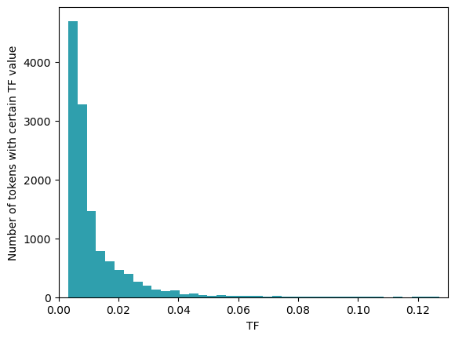

```python
# Creating a Gensim dictionary from the tokenized lyrics in the 'albums' dataframe
dictionary = corpora.Dictionary(albums['lyric'])

# Creating a corpus using Bag-of-Words (BoW) model
corpus = [dictionary.doc2bow(text) for text in albums['lyric']]

# Define a function to calculate Term Frequency (TF) for a specific document
def TF(dictionary, corpus, which_text):
    bow = dict(corpus[which_text])
    bow_dict_combined = dict((dictionary[key], value) for (key, value) in bow.items())
    TFdictionary = {}
    bow_count = sum(bow_dict_combined.values())

    # Calculate term frequency for each word in the document
    for word, count in bow_dict_combined.items():
        TFdictionary[word] = count/bow_count

    return TFdictionary

# Print term frequency for the first document in the corpus
print(TF(dictionary, corpus, 0))

# Initialize a dictionary to hold term frequencies for all documents
d = {}

# Calculate term frequencies for each document in the corpus
for i in range(0, len(corpus)):
    data = TF(dictionary, corpus, i)

    # Populate the dictionary with term frequencies for each token
    for token, tf in data.items():
        d.setdefault(token, []).append(tf)

# Flatten the list of term frequency values for all tokens
tf_values = [item for sublist in list(d.values()) for item in sublist]

# Plot a histogram of term frequency values across the corpus
plt.hist(tf_values, bins=100, color = '#2f9fad')
plt.xlabel('TF')
plt.ylabel('Number of tokens with certain TF value')
plt.xlim([0, 0.13]) # limit on x axis
plt.show()
```

```python
# Joining the lists of lyrics into single strings for each album
albums['lyric'] = [' '.join(lyrics) for lyrics in albums['lyric']]
print(albums['lyric'].head())
```

```
0    said way blue eye shined put georgia star sham...
1    state obvious get perfect fantasy realize love...
2    drew look fake smile see want needing everythi...
3    know want ask cause still trying figure know w...
4    way coming easily take take best start fight c...
Name: lyric, dtype: object
```

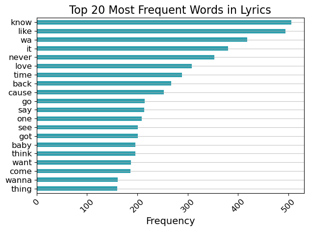

```python
all_words = ' '.join(albums['lyric'] ).lower().split()

# Filter for words
words = [word for word in all_words]

# Count the frequency of each word
word_freq = pd.Series(words).value_counts()

# Plot the top 20 most frequent words
word_freq[:20][::-1].plot(kind='barh', color='#2f9fad')
plt.xlabel('Frequency', fontsize=14)
plt.title('Top 20 Most Frequent Words in Lyrics', fontsize=16)
plt.xticks(rotation=45, fontsize=12)
plt.yticks(fontsize=12)
plt.grid(axis='y', linestyle='-', alpha=0.7)
plt.tight_layout()
plt.show()
```

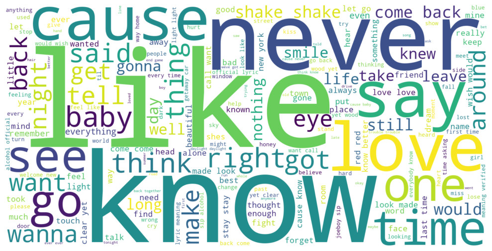

```python
# Generate a word cloud text
wordcloud_text = ' '.join(albums['lyric'])

# Generate a word cloud image with additional customizations
wordcloud = WordCloud(
    width=1600, height=800,
    background_color='white',
    max_words=200,
    stopwords=stop_words,
    colormap='viridis',
    contour_width=3, contour_color='steelblue'
).generate(wordcloud_text)

# Display the generated image
plt.figure(figsize=(10, 6))
plt.imshow(wordcloud, interpolation='bilinear')
plt.axis("off")
plt.tight_layout()
plt.show()
```

```python
tf_vectorizer = CountVectorizer(encoding = 'utf-8',
                                decode_error = 'strict',
                                lowercase = True, # all letters to lower case
                                ngram_range = (1, 3), # what kind of ngrams do we want
                                max_df = 0.8, # filtering with document frequency
                                min_df = 2, # filtering with document frequency
                                max_features = None,
)

tf = tf_vectorizer.fit_transform(albums['lyric'])
tf_feature_names = tf_vectorizer.get_feature_names_out()
tf_feature_names
```

```
array(['accident', 'ache', 'achilles', ..., 'york', 'young', 'younger'],
      dtype=object)
```

```python
# Duplicate the 'lyrics' column and name the new column 'lyrics2' for further steps
albums['lyric2'] = albums['lyric'].copy()
albums.head()
```

|  | track_n | track_title | album_name | lyric | lyric2 |
| --- | --- | --- | --- | --- | --- |
| 0 | 1 | Tim McGraw | Taylor Swift | said way blue eye shined put georgia star sham... | said way blue eye shined put georgia star sham... |
| 1 | 2 | Picture To Burn | Taylor Swift | state obvious get perfect fantasy realize love... | state obvious get perfect fantasy realize love... |
| 2 | 3 | Teardrops On My Guitar | Taylor Swift | drew look fake smile see want needing everythi... | drew look fake smile see want needing everythi... |
| 3 | 4 | A Place In This World | Taylor Swift | know want ask cause still trying figure know w... | know want ask cause still trying figure know w... |
| 4 | 5 | Cold As You | Taylor Swift | way coming easily take take best start fight c... | way coming easily take take best start fight c... |

```python
# Save the DataFrame to CSV
# albums.to_csv('Data//albums_merged_cleaned.csv', index=True)
```

## 3. Modeling

```python
def generate_ngrams(text, ngram = 1):
    temp = zip(*[text[i:] for i in range(0,ngram)]) # set with pairs, three, ..., ns of tokens
    ans = [' '.join(ngram) for ngram in temp] # joins the elements in strings
    ans = pd.Series(ans).map(lambda x: re.sub(" ", '_', x)) # replaces spaces with '_'
    return list(ans)

# UMass score
def get_umass_score(dt_matrix, i, j):
    zo_matrix = (dt_matrix > 0).astype(int)
    col_i, col_j = zo_matrix[:, i], zo_matrix[:, j]
    col_ij = col_i + col_j
    col_ij = (col_ij == 2).astype(int)
    Di, Dij = col_i.sum(), col_ij.sum()
    return math.log((Dij + 1) / Di)

# UCI score prepared basing on the above
def get_uci_score(dt_matrix, i, j):
    zo_matrix = (dt_matrix > 0).astype(int)
    col_i, col_j = zo_matrix[:, i], zo_matrix[:, j]
    col_ij = col_i + col_j
    col_ij = (col_ij == 2).astype(int)
    Di, Dj, Dij = col_i.sum(), col_j.sum(), col_ij.sum()
    return math.log((Dij + 1) / (Di*Dj))

# using NPMI instead of PMI in UCI score
def get_uci_npmi_score(dt_matrix, i, j):
    zo_matrix = (dt_matrix > 0).astype(int)
    col_i, col_j = zo_matrix[:, i], zo_matrix[:, j]
    col_ij = col_i + col_j
    col_ij = (col_ij == 2).astype(int)
    Di, Dj, Dij = col_i.sum(), col_j.sum(), col_ij.sum()
    return (math.log((Dij + 1) / (Di*Dj))) / (-math.log(Dij+1)+1) # slight modifications to avoid log(0) or dividing with 0

def get_topic_coherence(dt_matrix, topic, n_top_words, coherence_type):
    indexed_topic = zip(topic, range(0, len(topic)))
    topic_top = sorted(indexed_topic, key=lambda x: 1 - x[0])[0:n_top_words]
    coherence = 0
    if(coherence_type == "uci"):
        for j_index in range(0, len(topic_top)):
            for i_index in range(0, j_index - 1):
                i = topic_top[i_index][1]
                j = topic_top[j_index][1]
                coherence += get_uci_score(dt_matrix, i, j)
    if(coherence_type == "uci_npmi"):
        for j_index in range(0, len(topic_top)):
            for i_index in range(0, j_index - 1):
                i = topic_top[i_index][1]
                j = topic_top[j_index][1]
                coherence += get_uci_npmi_score(dt_matrix, i, j)
    if(coherence_type == "umass"):
        for j_index in range(0, len(topic_top)):
            for i_index in range(0, j_index - 1):
                i = topic_top[i_index][1]
                j = topic_top[j_index][1]
                coherence += get_umass_score(dt_matrix, i, j)
    return coherence

def get_average_topic_coherence(dt_matrix, topics, n_top_words, coherence_type):
    total_coherence = 0
    for i in range(0, len(topics)):
        total_coherence += get_topic_coherence(dt_matrix, topics[i], n_top_words, coherence_type)
    return total_coherence / len(topics)


def DF(corpus, dictionary):
    occurence = {}

    for i in range(0,len(corpus)):

        #corpus from gensim library consists of so called bows
        #every bow = keys are tokens' indexes; values are numbers of tokens' occurences in text
        bow = dict(corpus[i])

        #dict_combined = keys are tokens' names; values are numbers of tokens' occurences in text
        bow_dict_combined = dict((dictionary[key], value) for (key, value) in bow.items())

        # creates a dictionary where keys are tokens' names and values are lists of tokens' non-zero counts in texts
        for token, count in bow_dict_combined.items():
            occurence.setdefault(token, []).append(count)

    DFdictionary = {}

    # based on tokens' counts dictionary woth tokens' names and IDF values is computed
    for token, counts in occurence.items():
        DFdictionary[token] = len(counts)/len(corpus)

    return(DFdictionary)
```

### 3.1 Latent Semantic Analysis (LSA)

```python
# Preprocessing and N-Grams generation
for i in range(0,len(albums['lyric'])):
    unigrams = albums['lyric'][i]
    bigrams = generate_ngrams(albums['lyric'][i], ngram = 2)
    trigrams = generate_ngrams(albums['lyric'][i], ngram = 3)

    text = []
    text.append(unigrams)
    text.append(bigrams)
    text.append(trigrams)

    albums['lyric'][i] = [item for sublist in text for item in sublist]

lsa = TruncatedSVD(n_components = 10, #number of topics
                   n_iter = 50, #number of iterations, more iterations -> more accurate but slower
                                #we should rather use something around 100 but it would take more time...
                   random_state = 40) #random seed in aim of reproducibility

model = lsa.fit_transform(tf) #fitting model on data

for index, component in enumerate(lsa.components_): #taking model's components
                                                    #(values from reconstructed Document-Term Matrix)
    zipped = zip(tf_feature_names, component) #taking together tokens' names with components
    top_terms_key=sorted(zipped, key = lambda t: t[1], reverse=True)[:10] #top 10 terms per topic
    top_terms_list=list(dict(top_terms_key).keys()) #taking only tokens, no weights

    print("Topic "+str(index)+": ",top_terms_list) #prints top 10 tokens per topic

pd.options.mode.chained_assignment = None  # default='warn'
```

[output not shown]

[output cut: 625 more lines]

[output not shown]

```
Topic 0:  ['know', 'like', 'wa', 'it', 'never', 'love', 'back', 'time', 'cause', 'got']
Topic 1:  ['shake', 'gonna', 'fake', 'hate', 'play', 'break', 'play play', 'baby', 'people say', 'stop']
Topic 2:  ['wish', 'would', 'wish would', 'back', 'never', 'right', 'love', 'come', 'good', 'shake']
Topic 3:  ['wa', 'red', 'red red', 'yet', 'like', 'stay', 'never', 'wa like', 'loving', 'clear']
Topic 4:  ['yet', 'clear', 'good', 'love', 'remember', 'looking', 'love love', 'baby', 'came', 'last']
Topic 5:  ['love', 'love love', 'light', 'go', 'time', 'way', 'bad', 'new', 'way home', 'it']
Topic 6:  ['love', 'know', 'red', 'love love', 'red red', 'wanna', 'know better', 'shake', 'better', 'better know']
Topic 7:  ['new', 'new york', 'york', 'welcome', 'want', 'call', 'it', 'like', 'waiting', 'one']
Topic 8:  ['look', 'made', 'want', 'call', 'like', 'one', 'got', 'red', 'wish', 'love']
Topic 9:  ['come', 'back', 'come back', 'want', 'call', 'back come', 'back come back', 'come back come', 'like', 'ever']
```

[output not shown]

[output cut: 80 more lines]

[output not shown]

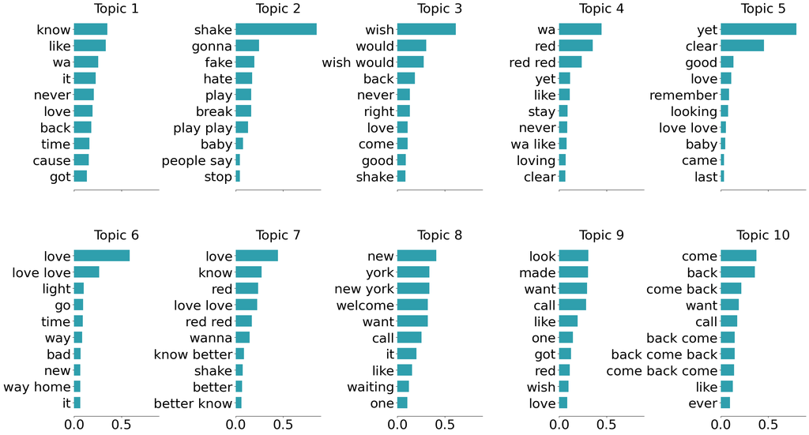

```python
def plot_top_words(model, feature_names, n_top_words, title = '', subplotx = 2, subploty = 5, size = (30, 15)):
    fig, axes = plt.subplots(subplotx, subploty, figsize=size, sharex=True)
    axes = axes.flatten()
    for topic_idx, topic in enumerate(model.components_):
        top_features_ind = topic.argsort()[: -n_top_words - 1 : -1]
        top_features = [feature_names[i] for i in top_features_ind]
        weights = topic[top_features_ind]

        ax = axes[topic_idx]
        ax.barh(top_features, weights, height=0.7,color = '#2f9fad')
        ax.set_title(f"Topic {topic_idx +1}", fontdict={"fontsize": 30})
        ax.invert_yaxis()
        ax.tick_params(axis="both", which="major", labelsize=30)
        for i in "top right left".split():
            ax.spines[i].set_visible(False)
        fig.suptitle(title, fontsize=40)

    plt.subplots_adjust(top=0.90, bottom=0.05, wspace=0.90, hspace=0.3)
    plt.show()

plot_top_words(lsa, tf_feature_names, 10, title = '', subplotx = 2, subploty = 5)
```

The model have identified a mix of emotions and themes often found in music lyrics, such as love, desire, regret, and the significance of places and memories. The inclusion of bigrams and trigrams, like "play play," "wish would," "red red," "love love," "new york," and "come back come," let us provide a richer context than unigrams alone.

### 3.2 Latent Dirichlet Allocation (LDA)

```
Trying parameters: 2
Trying parameters: 3
Trying parameters: 4
Trying parameters: 5
Trying parameters: 6
Trying parameters: 7
Trying parameters: 8
Trying parameters: 9
Trying parameters: 10
Trying parameters: 11
Trying parameters: 12
Trying parameters: 13
Trying parameters: 14
Trying parameters: 15
Trying parameters: 16
Trying parameters: 17
Trying parameters: 18
Trying parameters: 19
Trying parameters: 20
Trying parameters: 21
Trying parameters: 22
Trying parameters: 23
Trying parameters: 24
Trying parameters: 25
```

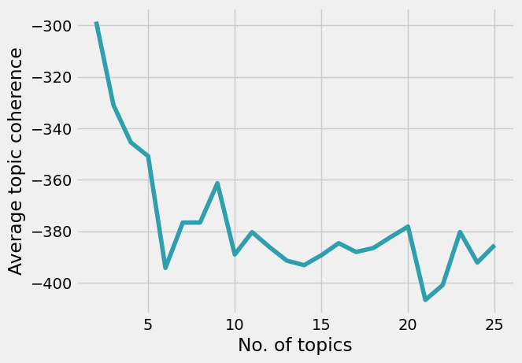

```python
dictionary = corpora.Dictionary(albums['lyric']) # using the column with preprocessed data in form of tokens
                                                # in lists not as strings
corpus = [dictionary.doc2bow(text) for text in albums['lyric']] # same as above

DFdictionary = DF(corpus, dictionary)
len(DFdictionary)
dict(sorted(DFdictionary.items(), key=lambda item: item[1], reverse=True))

topic_coherence_specific = []

for n_topics in range(2,26,1):

    print('Trying parameters:', n_topics)

    lda = LatentDirichletAllocation(n_components = n_topics, random_state = 40)
    #less iterations used above to not wait till tomorrow, results will be less precise though

    lda.fit_transform(tf)

    avg_coherence = get_average_topic_coherence(tf, lda.components_, 25, 'umass')

    topic_coherence_specific.append([avg_coherence, n_topics])
# below, we make the output (list) a pandas DataFrame with intuitive colnames
topic_coherence_specific_df = pd.DataFrame(topic_coherence_specific).rename(columns={
    0: 'avg_coherence', 1: 'n_topics'
})

plt.style.use("fivethirtyeight")
plt.plot(topic_coherence_specific_df['n_topics'],topic_coherence_specific_df['avg_coherence'], color = '#2f9fad')
plt.xlabel("No. of topics")
plt.ylabel("Average topic coherence")
plt.show()
```

```python
topic_coherence_specific_df.sort_values('avg_coherence', ascending = False).iloc[0:9,:]
```

|  | avg_coherence | n_topics |
| --- | --- | --- |
| 0 | -298.542253 | 2 |
| 1 | -330.996667 | 3 |
| 2 | -345.472071 | 4 |
| 3 | -350.840854 | 5 |
| 7 | -361.389584 | 9 |
| 6 | -376.664775 | 8 |
| 5 | -376.683767 | 7 |
| 18 | -378.228065 | 20 |
| 21 | -380.342192 | 23 |

From the graph, we can see a general trend where the average topic coherence decreases as the number of topics increases. The highest coherence score is -298 for 2 topics. However, having only 2 topics might be too broad and general.

```
Trying parameters: 2
Trying parameters: 3
Trying parameters: 4
Trying parameters: 5
Trying parameters: 6
Trying parameters: 7
Trying parameters: 8
Trying parameters: 9
Trying parameters: 10
Trying parameters: 11
Trying parameters: 12
Trying parameters: 13
Trying parameters: 14
Trying parameters: 15
Trying parameters: 16
Trying parameters: 17
Trying parameters: 18
Trying parameters: 19
Trying parameters: 20
Trying parameters: 21
Trying parameters: 22
Trying parameters: 23
Trying parameters: 24
Trying parameters: 25
```

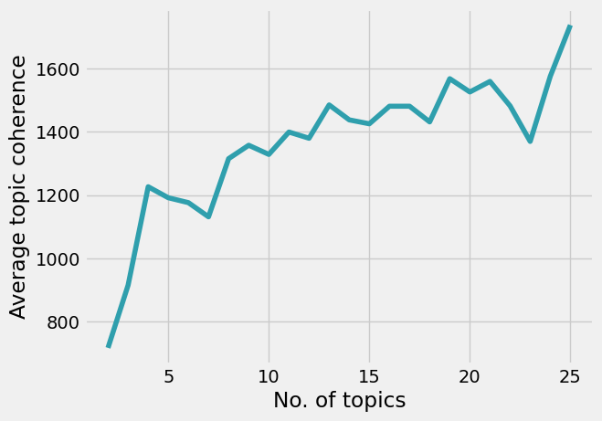

```python
dictionary = corpora.Dictionary(albums['lyric']) # using the column with preprocessed data in form of tokens
                                                # in lists not as strings
corpus = [dictionary.doc2bow(text) for text in albums['lyric']] # same as above

DFdictionary = DF(corpus, dictionary)
len(DFdictionary)
dict(sorted(DFdictionary.items(), key=lambda item: item[1], reverse=True))

topic_coherence_specific = []

for n_topics in range(2,26,1):

    print('Trying parameters:', n_topics)

    lda = LatentDirichletAllocation(n_components = n_topics, random_state = 40)
    #less iterations used above to not wait till tomorrow, results will be less precise though

    lda.fit_transform(tf)

    avg_coherence = get_average_topic_coherence(tf, lda.components_, 25, 'uci_npmi')

    topic_coherence_specific.append([avg_coherence, n_topics])
# below, we make the output (list) a pandas DataFrame with intuitive colnames
topic_coherence_specific_df = pd.DataFrame(topic_coherence_specific).rename(columns={
    0: 'avg_coherence', 1: 'n_topics'
})

plt.style.use("fivethirtyeight")
plt.plot(topic_coherence_specific_df['n_topics'],topic_coherence_specific_df['avg_coherence'], color = '#2f9fad')
plt.xlabel("No. of topics")
plt.ylabel("Average topic coherence")
plt.show()
```

```python
topic_coherence_specific_df.sort_values('avg_coherence', ascending = False).iloc[0:9,:]
```

|  | avg_coherence | n_topics |
| --- | --- | --- |
| 23 | 1738.027365 | 25 |
| 22 | 1576.070954 | 24 |
| 17 | 1568.348803 | 19 |
| 19 | 1559.712477 | 21 |
| 18 | 1526.344802 | 20 |
| 11 | 1485.371444 | 13 |
| 20 | 1482.325132 | 22 |
| 15 | 1481.256306 | 17 |
| 14 | 1481.217493 | 16 |

From the graph, we can see a general trend where the average topic coherence increases as the number of topics increases. The highest coherence score is 1738 for 25 topics.

```
Trying parameters: 2
Trying parameters: 3
Trying parameters: 4
Trying parameters: 5
Trying parameters: 6
Trying parameters: 7
Trying parameters: 8
Trying parameters: 9
Trying parameters: 10
Trying parameters: 11
Trying parameters: 12
Trying parameters: 13
Trying parameters: 14
Trying parameters: 15
Trying parameters: 16
Trying parameters: 17
Trying parameters: 18
Trying parameters: 19
Trying parameters: 20
Trying parameters: 21
Trying parameters: 22
Trying parameters: 23
Trying parameters: 24
Trying parameters: 25
```

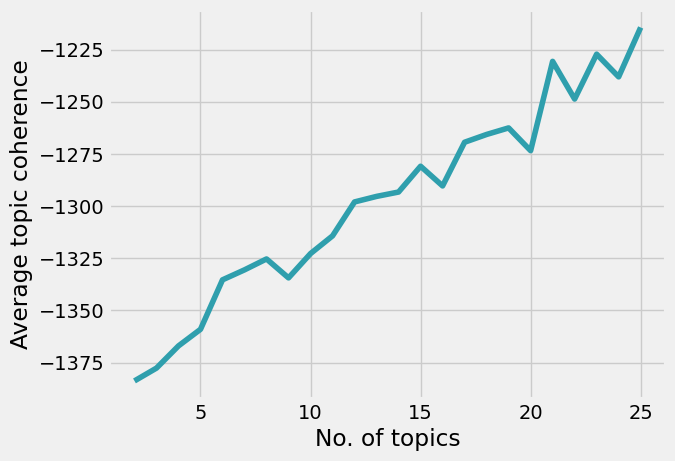

```python
dictionary = corpora.Dictionary(albums['lyric']) # using the column with preprocessed data in form of tokens
                                                # in lists not as strings
corpus = [dictionary.doc2bow(text) for text in albums['lyric']] # same as above

DFdictionary = DF(corpus, dictionary)
len(DFdictionary)
dict(sorted(DFdictionary.items(), key=lambda item: item[1], reverse=True))

topic_coherence_specific = []

for n_topics in range(2,26,1):

    print('Trying parameters:', n_topics)

    lda = LatentDirichletAllocation(n_components = n_topics, random_state = 40)
    #less iterations used above to not wait till tomorrow, results will be less precise though

    lda.fit_transform(tf)

    avg_coherence = get_average_topic_coherence(tf, lda.components_, 25, 'uci')

    topic_coherence_specific.append([avg_coherence, n_topics])
# below, we make the output (list) a pandas DataFrame with intuitive colnames
topic_coherence_specific_df = pd.DataFrame(topic_coherence_specific).rename(columns={
    0: 'avg_coherence', 1: 'n_topics'
})

plt.style.use("fivethirtyeight")
plt.plot(topic_coherence_specific_df['n_topics'],topic_coherence_specific_df['avg_coherence'], color = '#2f9fad')
plt.xlabel("No. of topics")
plt.ylabel("Average topic coherence")
plt.show()
```

```python
topic_coherence_specific_df.sort_values('avg_coherence', ascending = False).iloc[0:9,:]
```

|  | avg_coherence | n_topics |
| --- | --- | --- |
| 23 | -1214.411878 | 25 |
| 21 | -1227.222328 | 23 |
| 19 | -1230.665644 | 21 |
| 22 | -1238.086049 | 24 |
| 20 | -1248.719058 | 22 |
| 17 | -1262.548823 | 19 |
| 16 | -1265.688926 | 18 |
| 15 | -1269.417611 | 17 |
| 18 | -1273.455561 | 20 |

From the graph, we can see a general trend where the average topic coherence increases as the number of topics increases. The highest coherence score is -1214 for 25 topics. So based on uci and uci_npmi coherence measures we will use 25 number of components.

```python
lda = LatentDirichletAllocation(n_components = 25,
                   random_state = 40)

model = lda.fit_transform(tf)

for index, component in enumerate(lda.components_):
    zipped = zip(tf_feature_names, component)
    top_terms_key=sorted(zipped, key = lambda t: t[1], reverse=True)[:10]
    top_terms_list=list(dict(top_terms_key).keys())

    print("Topic "+str(index)+": ",top_terms_list)
```

```
Topic 0:  ['like', 'come', 'one', 'it', 'wa', 'cause', 'time', 'get', 'know', 'help']
Topic 1:  ['shake', 'know', 'look', 'made', 'like', 'it', 'cause', 'gonna', 'want', 'got']
Topic 2:  ['love', 'way', 'way home', 'home', 'silence', 'light', 'know', 'light light', 'wa', 'meet']
Topic 3:  ['ever', 'go', 'never', 'trouble', 'back', 'talk', 'love', 'know', 'got', 'cause']
Topic 4:  ['know', 'he', 'got', 'everybody', 'look', 'home', 'girl', 'song', 'got girl', 'cause']
Topic 5:  ['got', 'love', 'weve', 'like', 'think', 'know', 'baby', 'blood', 'cause', 'bad']
Topic 6:  ['it', 'never', 'know', 'wa', 'go', 'see', 'back', 'said', 'like', 'thing']
Topic 7:  ['back', 'love', 'come back', 'come', 'love love', 'back come', 'back come back', 'come back come', 'like', 'wa']
Topic 8:  ['follow', 'good', 'take', 'say', 'get', 'dress', 'treacherous', 'follow follow', 'light', 'home']
Topic 9:  ['mean', 'watch', 'someday', 'big', 'away', 'day', 'ever', 'gonna', 'got', 'fly']
Topic 10:  ['wish', 'would', 'time', 'last', 'wish would', 'last time', 'asking', 'dancing', 'hand', 'right']
Topic 11:  ['begin', 'let', 'dream', 'game', 'night', 'know', 'baby', 'see', 'middle', 'middle night']
Topic 12:  ['wa', 'man', 'rain', 'man man', 'forever always', 'said forever', 'said forever always', 'forever', 'always', 'said']
Topic 13:  ['call', 'want', 'wa', 'one', 'know', 'baby', 'like', 'would', 'think', 'thing']
Topic 14:  ['know', 'better', 'never', 'know better', 'walk', 'street', 'better know', 'thing', 'nice', 'wanna']
Topic 15:  ['stay', 'stay stay', 'stay stay stay', 'time', 'waiting', 'see', 'mad', 'right', 'it', 'see right']
Topic 16:  ['wanna', 'like', 'time', 'know', 'never', 'love', 'baby', 'new', 'york', 'new york']
Topic 17:  ['wa', 'know', 'it', 'like', 'stay', 'love', 'say', 'hey', 'never', 'wanna']
Topic 18:  ['want', 'ever', 'girl', 'one', 'grow', 'one want', 'work', 'darling', 'get', 'never']
Topic 19:  ['time', 'marvelous', 'go', 'everything', 'wa', 'seen', 'town', 'woman', 'ha', 'house']
Topic 20:  ['yet', 'clear', 'like', 'need', 'know', 'night', 'see', 'it', 'good', 'feel']
Topic 21:  ['never', 'like', 'see', 'right', 'sign', 'way', 'love', 'time', 'gave', 'smile']
Topic 22:  ['like', 'meaning verified', 'official', 'verified', 'lyric', 'official lyric meaning', 'lyric meaning', 'lyric meaning verified', 'official lyric', 'meaning']
Topic 23:  ['wa', 'shes', 'today', 'fairytale', 'way', 'must', 'think', 'better', 'feel', 'keep']
Topic 24:  ['red', 'wa', 'like', 'red red', 'come', 'say', 'come come', 'wa like', 'never', 'burning']
```

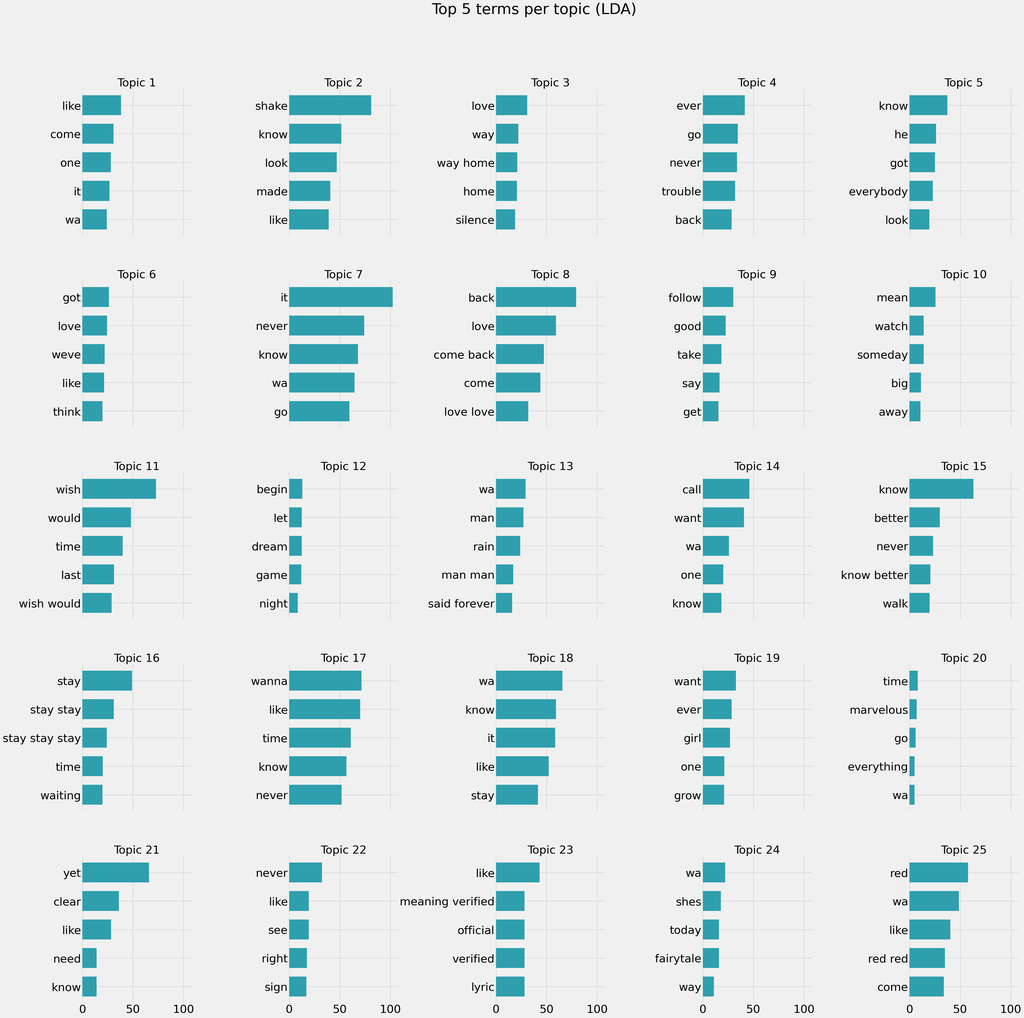

```python
plot_top_words(lda, tf_feature_names, n_top_words=5, title='Top 5 terms per topic (LDA)',
               subplotx=5, subploty=5, size=(40, 40))
```

The model has been trained on some text data, and it has inferred 25 different topics. We can infer that the LDA model has found a variety of topics with words that seem to suggest different themes or subjects. For example:

- Topic 2 has words like "love," "way," "home," "silence," suggesting themes of relationships or emotion.
- Topic 7 is heavily focused on the concept of "back" and "come back," and "love," indicating a theme of return or reconciliation.
- Topic 10 features words like "wish," "would," "time," and "last," which might be connected to desires, wishes or reflective thoughts.

### 3.3 Probabilistic Latent Semantic Analysis (PLSA)

```
Trying parameters: 2
```

```
Trying parameters: 3
Trying parameters: 4
Trying parameters: 5
Trying parameters: 6
Trying parameters: 7
Trying parameters: 8
Trying parameters: 9
Trying parameters: 10
Trying parameters: 11
Trying parameters: 12
Trying parameters: 13
Trying parameters: 14
Trying parameters: 15
Trying parameters: 16
Trying parameters: 17
Trying parameters: 18
Trying parameters: 19
Trying parameters: 20
Trying parameters: 21
Trying parameters: 22
Trying parameters: 23
Trying parameters: 24
Trying parameters: 25
```

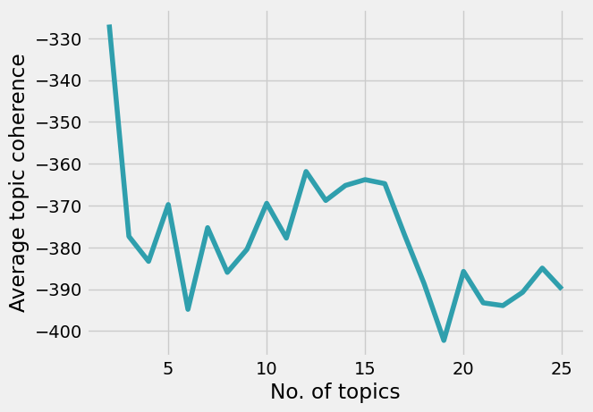

```python
topic_coherence_specific = []
for n_topics in range(2,26,1):
    print('Trying parameters:', n_topics)
    plsa = NMF(n_components = n_topics,
               max_iter = 25,
               init = None,
               solver = 'mu',
               beta_loss = 'kullback-leibler',
               alpha_W = 0,
               alpha_H = 'same',
               l1_ratio = 0,
               random_state = 40
              )
    plsa.fit_transform(tf)
    avg_coherence = get_average_topic_coherence(tf, plsa.components_, 25, 'umass')
    topic_coherence_specific.append([avg_coherence, n_topics])
# below, we make the output (list) a pandas DataFrame with intuitive colnames
topic_coherence_specific_df_plsa = pd.DataFrame(topic_coherence_specific).rename(columns={
    0: 'avg_coherence', 1: 'n_topics'
})

plt.style.use("fivethirtyeight")
plt.plot(
    topic_coherence_specific_df_plsa['n_topics'],
    topic_coherence_specific_df_plsa['avg_coherence'],
    color='#2f9fad')
plt.xlabel("No. of topics")
plt.ylabel("Average topic coherence")
plt.show()
```

```python
topic_coherence_specific_df_plsa.sort_values('avg_coherence', ascending = False).iloc[0:9,:]
```

|  | avg_coherence | n_topics |
| --- | --- | --- |
| 0 | -326.711482 | 2 |
| 10 | -361.854972 | 12 |
| 13 | -363.800655 | 15 |
| 14 | -364.754699 | 16 |
| 12 | -365.185128 | 14 |
| 11 | -368.778694 | 13 |
| 8 | -369.457274 | 10 |
| 3 | -369.758966 | 5 |
| 5 | -375.283769 | 7 |

From the graph, we can see a trend where the average topic coherence decreases as the number of topics increases and in the middle it has a short increase. The highest coherence score is -326 for 2 topics.

```
Trying parameters: 2
```

```
Trying parameters: 3
Trying parameters: 4
Trying parameters: 5
Trying parameters: 6
Trying parameters: 7
Trying parameters: 8
Trying parameters: 9
Trying parameters: 10
Trying parameters: 11
Trying parameters: 12
Trying parameters: 13
Trying parameters: 14
Trying parameters: 15
Trying parameters: 16
Trying parameters: 17
Trying parameters: 18
Trying parameters: 19
Trying parameters: 20
Trying parameters: 21
Trying parameters: 22
Trying parameters: 23
Trying parameters: 24
Trying parameters: 25
```

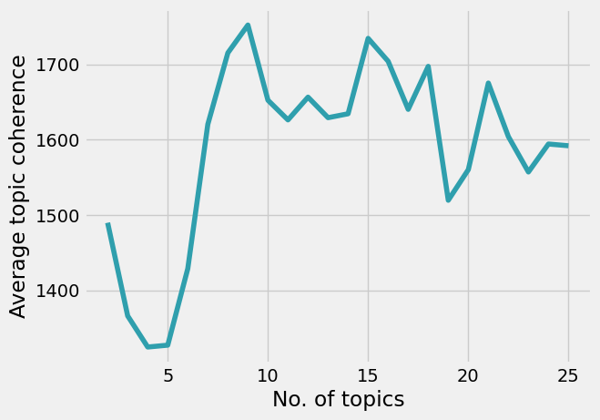

```python
topic_coherence_specific = []
for n_topics in range(2,26,1):
    print('Trying parameters:', n_topics)
    plsa = NMF(n_components = n_topics,
               max_iter = 25,
               init = None,
               solver = 'mu',
               beta_loss = 'kullback-leibler',
               alpha_W = 0,
               alpha_H = 'same',
               l1_ratio = 0,
               random_state = 40
              )
    plsa.fit_transform(tf)
    avg_coherence = get_average_topic_coherence(tf, plsa.components_, 25, 'uci_npmi')
    topic_coherence_specific.append([avg_coherence, n_topics])
# below, we make the output (list) a pandas DataFrame with intuitive colnames
topic_coherence_specific_df_plsa = pd.DataFrame(topic_coherence_specific).rename(columns={
    0: 'avg_coherence', 1: 'n_topics'
})

plt.style.use("fivethirtyeight")
plt.plot(
    topic_coherence_specific_df_plsa['n_topics'],
    topic_coherence_specific_df_plsa['avg_coherence'],
    color='#2f9fad')
plt.xlabel("No. of topics")
plt.ylabel("Average topic coherence")
plt.show()
```

```python
topic_coherence_specific_df_plsa.sort_values('avg_coherence', ascending = False).iloc[0:9,:]
```

|  | avg_coherence | n_topics |
| --- | --- | --- |
| 7 | 1752.089920 | 9 |
| 13 | 1734.349604 | 15 |
| 6 | 1715.087687 | 8 |
| 14 | 1703.915427 | 16 |
| 16 | 1697.187419 | 18 |
| 19 | 1675.044661 | 21 |
| 10 | 1656.338568 | 12 |
| 8 | 1652.249126 | 10 |
| 15 | 1640.091484 | 17 |

From the graph, we can see a general trend where the average topic coherence increases as the number of topics increases for the 10 topics and then the line has not specific trend. The highest coherence score is 1752 for 9 topics.

```
Trying parameters: 2
```

```
Trying parameters: 3
Trying parameters: 4
Trying parameters: 5
Trying parameters: 6
Trying parameters: 7
Trying parameters: 8
Trying parameters: 9
Trying parameters: 10
Trying parameters: 11
Trying parameters: 12
Trying parameters: 13
Trying parameters: 14
Trying parameters: 15
Trying parameters: 16
Trying parameters: 17
Trying parameters: 18
Trying parameters: 19
Trying parameters: 20
Trying parameters: 21
Trying parameters: 22
Trying parameters: 23
Trying parameters: 24
Trying parameters: 25
```

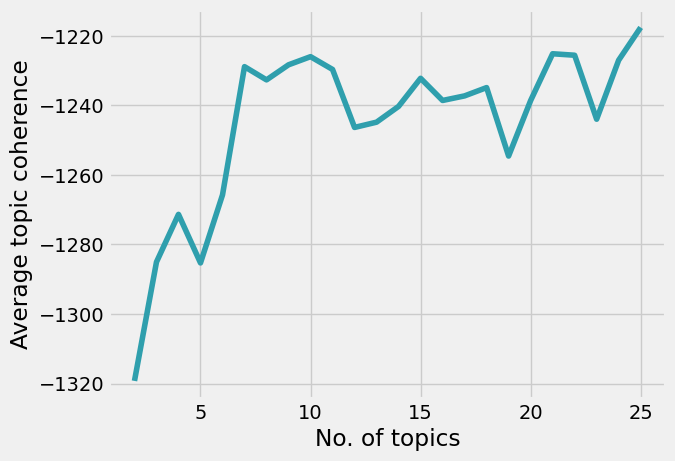

```python
topic_coherence_specific = []
for n_topics in range(2,26,1):
    print('Trying parameters:', n_topics)
    plsa = NMF(n_components = n_topics,
               max_iter = 25,
               init = None,
               solver = 'mu',
               beta_loss = 'kullback-leibler',
               alpha_W = 0,
               alpha_H = 'same',
               l1_ratio = 0,
               random_state = 40
              )
    plsa.fit_transform(tf)
    avg_coherence = get_average_topic_coherence(tf, plsa.components_, 25, 'uci')
    topic_coherence_specific.append([avg_coherence, n_topics])
# below, we make the output (list) a pandas DataFrame with intuitive colnames
topic_coherence_specific_df_plsa = pd.DataFrame(topic_coherence_specific).rename(columns={
    0: 'avg_coherence', 1: 'n_topics'
})

plt.style.use("fivethirtyeight")
plt.plot(
    topic_coherence_specific_df_plsa['n_topics'],
    topic_coherence_specific_df_plsa['avg_coherence'],
    color='#2f9fad')
plt.xlabel("No. of topics")
plt.ylabel("Average topic coherence")
plt.show()
```

```python
topic_coherence_specific_df_plsa.sort_values('avg_coherence', ascending = False).iloc[0:9,:]
```

|  | avg_coherence | n_topics |
| --- | --- | --- |
| 23 | -1217.571495 | 25 |
| 19 | -1225.138808 | 21 |
| 20 | -1225.560438 | 22 |
| 8 | -1225.973598 | 10 |
| 22 | -1226.997085 | 24 |
| 7 | -1228.316852 | 9 |
| 5 | -1228.849068 | 7 |
| 9 | -1229.650410 | 11 |
| 13 | -1232.196271 | 15 |

Since there's a big spread between different coherence measures, we will choose the number of topics 9 has the highest UCI-NPMI score.

```python
plsa = NMF(n_components = 9, # number of topics
           max_iter = 25, # maximum number of iterations to be made
           init = None, # what W and H should be the 'staring guess'
                        # possible options depend on sparseness or
                        # number of 0s there; {'random', 'nndsvd',
                        # 'nndsvda', 'nndvdar', 'custom', None};
                        # None means either 'nndsvda' or 'random'
                        # which depends on sample and feature sizes
           solver = 'mu', # Multiplicative Update ('mu')
           beta_loss = 'kullback-leibler', # what type of distance metric should be minimized;
                                           # we aim at PLSA, so it has to be 'kullback-leibler'
           # let us neglect regularization as we aim at PLSA
           alpha_W = 0,
           alpha_H = 'same',
           l1_ratio = 0,
           random_state = 40 # random seed in aim of reproducibility
          )
model = plsa.fit_transform(tf) # fitting model on data
for index, component in enumerate(plsa.components_): #taking model's components
                                                    #(values from reconstructed Document-Term Matrix)
    zipped = zip(tf_feature_names, component) #taking together tokens' names with components
    top_terms_key=sorted(zipped, key = lambda t: t[1], reverse=True)[:10] #top 10 terms per topic
    top_terms_list=list(dict(top_terms_key).keys()) #taking only tokens, no weights
    print("Topic "+str(index)+": ",top_terms_list) #prints top 10 tokens per topic
```

```
Topic 0:  ['know', 'never', 'wa', 'like', 'it', 'cause', 'time', 'go', 'see', 'thing']
Topic 1:  ['shake', 'never', 'play', 'gonna', 'fake', 'hate', 'break', 'love', 'need', 'like']
Topic 2:  ['back', 'would', 'wish', 'come', 'never', 'ever', 'come back', 'knew', 'right', 'he']
Topic 3:  ['wa', 'red', 'like', 'red red', 'stay', 'man', 'rain', 'back', 'never', 'hey']
Topic 4:  ['yet', 'clear', 'follow', 'follow follow', 'treacherous', 'home', 'follow follow home', 'follow home', 'happiness', 'get']
Topic 5:  ['love', 'time', 'it', 'stay', 'way', 'light', 'say', 'love love', 'good', 'let']
Topic 6:  ['know', 'wanna', 'like', 'love', 'better', 'it', 'know better', 'end', 'one', 'game']
Topic 7:  ['new', 'it', 'new york', 'york', 'waiting', 'like', 'girl', 'welcome', 'want', 'body']
Topic 8:  ['like', 'want', 'know', 'look', 'made', 'one', 'call', 'got', 'think', 'baby']
```

[figure not shown]

```python
plot_top_words(plsa, tf_feature_names, n_top_words=8, title='Top 5 terms per topic (PLSA)',
               subplotx=3, subploty=3, size=(30, 25))
```

### 3.4 Sentiment analysis

```python
albums2 = pd.read_csv('Data//albums_merged_cleaned.csv')
albums2.head()
```

|  | Unnamed: 0 | track_n | track_title | album_name | lyric | lyric2 |
| --- | --- | --- | --- | --- | --- | --- |
| 0 | 0 | 1 | Tim McGraw | Taylor Swift | said way blue eye shined put georgia star sham... | said way blue eye shined put georgia star sham... |
| 1 | 1 | 2 | Picture To Burn | Taylor Swift | state obvious get perfect fantasy realize love... | state obvious get perfect fantasy realize love... |
| 2 | 2 | 3 | Teardrops On My Guitar | Taylor Swift | drew look fake smile see want needing everythi... | drew look fake smile see want needing everythi... |
| 3 | 3 | 4 | A Place In This World | Taylor Swift | know want ask cause still trying figure know w... | know want ask cause still trying figure know w... |
| 4 | 4 | 5 | Cold As You | Taylor Swift | way coming easily take take best start fight c... | way coming easily take take best start fight c... |

```python
# Download the VADER lexicon
nltk.download('vader_lexicon')

# Initialize the SentimentIntensityAnalyzer
sia = SentimentIntensityAnalyzer()

# Apply sentiment analysis to each set of lyrics
albums2['sentiments'] = albums2['lyric2'].apply(lambda lyrics: sia.polarity_scores(lyrics))

# Extract compound scores
albums2['compound'] = albums2['sentiments'].apply(lambda sentiment: sentiment['compound'])

# Categorize sentiments based on the compound score
albums2['sentiment_category'] = albums2['compound'].apply(lambda x: 'positive' if x > 0 else ('negative' if x < 0 else 'neutral'))

albums2.head()
```

|  | Unnamed: 0 | track_n | track_title | album_name | lyric | lyric2 | sentiments | compound | sentiment_category |
| --- | --- | --- | --- | --- | --- | --- | --- | --- | --- |
| 0 | 0 | 1 | Tim McGraw | Taylor Swift | said way blue eye shined put georgia star sham... | said way blue eye shined put georgia star sham... | {'neg': 0.046, 'neu': 0.69, 'pos': 0.264, 'com... | 0.9938 | positive |
| 1 | 1 | 2 | Picture To Burn | Taylor Swift | state obvious get perfect fantasy realize love... | state obvious get perfect fantasy realize love... | {'neg': 0.448, 'neu': 0.453, 'pos': 0.099, 'co... | -0.9978 | negative |
| 2 | 2 | 3 | Teardrops On My Guitar | Taylor Swift | drew look fake smile see want needing everythi... | drew look fake smile see want needing everythi... | {'neg': 0.063, 'neu': 0.638, 'pos': 0.298, 'co... | 0.9900 | positive |
| 3 | 3 | 4 | A Place In This World | Taylor Swift | know want ask cause still trying figure know w... | know want ask cause still trying figure know w... | {'neg': 0.164, 'neu': 0.615, 'pos': 0.221, 'co... | 0.7269 | positive |
| 4 | 4 | 5 | Cold As You | Taylor Swift | way coming easily take take best start fight c... | way coming easily take take best start fight c... | {'neg': 0.252, 'neu': 0.509, 'pos': 0.24, 'com... | 0.3041 | positive |

```
                    album_name  avg_compound                  sentiment_count
0                1989 (Deluxe)      0.268731  {'positive': 10, 'negative': 6}
1  Fearless (Taylor’s Version)      0.691273  {'positive': 22, 'negative': 4}
2                        Lover      0.363683  {'positive': 12, 'negative': 6}
3         Red (Deluxe Edition)      0.811618  {'positive': 21, 'negative': 1}
4           Speak Now (Deluxe)      0.423476  {'positive': 12, 'negative': 5}
5                 Taylor Swift      0.771527  {'positive': 14, 'negative': 1}
6    evermore (deluxe version)      0.059800   {'positive': 9, 'negative': 8}
7    folklore (deluxe version)      0.246776  {'positive': 11, 'negative': 6}
8                   reputation      0.736373  {'positive': 13, 'negative': 2}
```

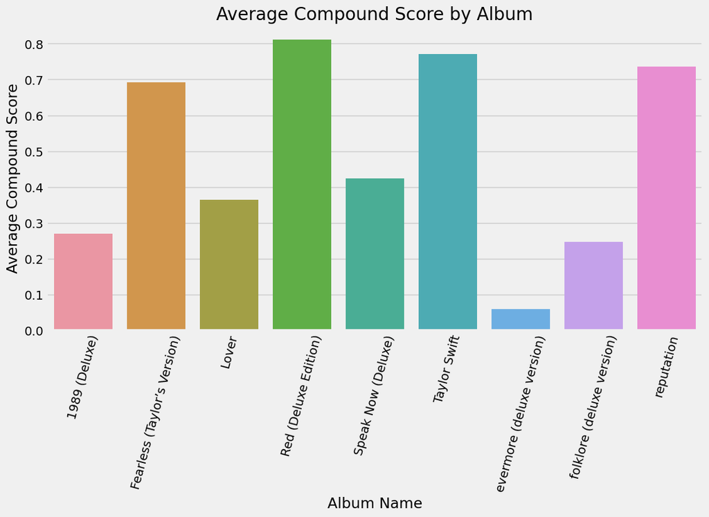

```python
# Grouping by album name and calculating mean sentiment scores and sentiment counts
album_sentiment_analysis = albums2.groupby('album_name').agg(
    avg_compound=('compound', 'mean'),  # Average compound score
    sentiment_count=('sentiment_category', lambda x: x.value_counts().to_dict())  # Count of sentiment categories
).reset_index()

# Displaying the result
print(album_sentiment_analysis)

# Visualizing the average compound score for each album
plt.figure(figsize=(12, 6))
sns.barplot(x='album_name', y='avg_compound', data=album_sentiment_analysis)
plt.title('Average Compound Score by Album')
plt.xlabel('Album Name')
plt.ylabel('Average Compound Score')
plt.xticks(rotation=75)
plt.show()
```

```python
# Merge the topic frequency DataFrame with the topic sentiment DataFrame
albums2 = pd.merge(albums2, album_sentiment_analysis, how='inner', on='album_name')
albums2.head()
```

|  | Unnamed: 0 | track_n | track_title | album_name | lyric | lyric2 | sentiments | compound | sentiment_category | avg_compound | sentiment_count |
| --- | --- | --- | --- | --- | --- | --- | --- | --- | --- | --- | --- |
| 0 | 0 | 1 | Tim McGraw | Taylor Swift | said way blue eye shined put georgia star sham... | said way blue eye shined put georgia star sham... | {'neg': 0.046, 'neu': 0.69, 'pos': 0.264, 'com... | 0.9938 | positive | 0.771527 | {'positive': 14, 'negative': 1} |
| 1 | 1 | 2 | Picture To Burn | Taylor Swift | state obvious get perfect fantasy realize love... | state obvious get perfect fantasy realize love... | {'neg': 0.448, 'neu': 0.453, 'pos': 0.099, 'co... | -0.9978 | negative | 0.771527 | {'positive': 14, 'negative': 1} |
| 2 | 2 | 3 | Teardrops On My Guitar | Taylor Swift | drew look fake smile see want needing everythi... | drew look fake smile see want needing everythi... | {'neg': 0.063, 'neu': 0.638, 'pos': 0.298, 'co... | 0.9900 | positive | 0.771527 | {'positive': 14, 'negative': 1} |
| 3 | 3 | 4 | A Place In This World | Taylor Swift | know want ask cause still trying figure know w... | know want ask cause still trying figure know w... | {'neg': 0.164, 'neu': 0.615, 'pos': 0.221, 'co... | 0.7269 | positive | 0.771527 | {'positive': 14, 'negative': 1} |
| 4 | 4 | 5 | Cold As You | Taylor Swift | way coming easily take take best start fight c... | way coming easily take take best start fight c... | {'neg': 0.252, 'neu': 0.509, 'pos': 0.24, 'com... | 0.3041 | positive | 0.771527 | {'positive': 14, 'negative': 1} |

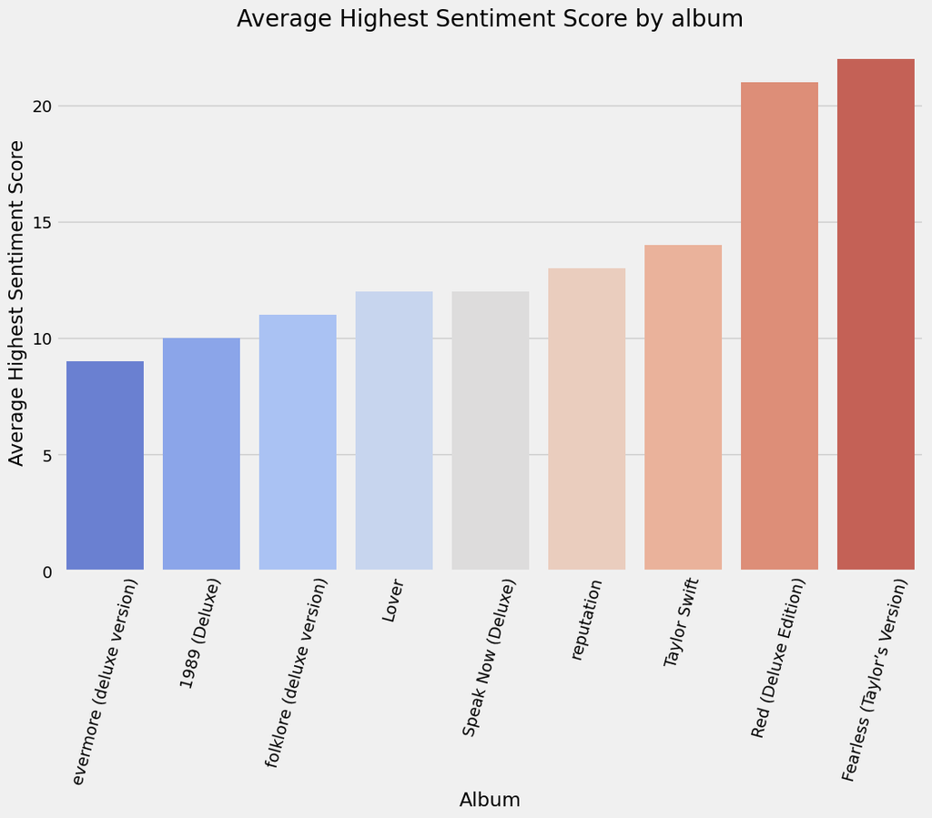

```python
# Adding a Column for the Highest Score
def get_highest_sentiment_score(row):
    # Extract sentiment scores and find the highest one
    scores = row['sentiment_count'].values()
    highest_score = max(scores) if scores else None
    return highest_score

# Apply the function to each row
albums2['highest_score'] = albums2.apply(get_highest_sentiment_score, axis=1)

# Group by topic (or another category if you have one) and aggregate the highest scores
highest_score = albums2.groupby('album_name')['highest_score'].mean().sort_values()

plt.figure(figsize=(12, 8))
sns.barplot(x=highest_score.index, y=highest_score.values, palette='coolwarm')
plt.title('Average Highest Sentiment Score by album')
plt.xlabel('Album')
plt.ylabel('Average Highest Sentiment Score')
plt.xticks(rotation=75)
plt.show()
```

```python
# Group by topic and calculate the sentiment distribution
topic_sentiment_corr = albums2.groupby('album_name')['sentiment_category'].value_counts(normalize=True).unstack(fill_value=0)

# Converting the DataFrame to a format suitable for Plotly
df_for_plotly = topic_sentiment_corr.reset_index().melt(id_vars='album_name', var_name='Sentiment', value_name='Percentage')

# Creating an interactive bar chart
fig = px.bar(df_for_plotly, x='album_name', y='Percentage', color='Sentiment', barmode='group')
fig.update_layout(title='Interactive Sentiment Distribution Across Topics',
                  xaxis_title='album',
                  yaxis_title='Percentage of Sentiments',
                  legend_title='Sentiment')
fig.show()
```

[output not shown]

## 4. Evaluation

The evaluation of the obtained results reveals the nuanced and dynamic nature of Taylor Swift's lyrical content, showcasing a significant emotional and thematic range across her discography. The analysis underscores the effectiveness of sentiment analysis and topic modeling in capturing the essence of her music, highlighting her evolution as an artist. These results reflect the quality and depth of Swift's work, providing valuable insights into her creative expression and its impact on listeners.

## 5. Summary

The sentiment and topic analysis of Taylor Swift's discography aimed to delve into the emotional depth and thematic diversity of her music over time. The project effectively utilized a dataset encompassing albums from different periods of her career, allowing for a broad analysis of lyrical content and the evolution of themes and sentiments in her work.

For the LDA model, a range of topics were evaluated to determine the optimal number of topics for the analysis. The topic coherence measure was utilized to find the most coherent topics, with the highest coherence score suggesting that 25 topics were most suitable for capturing the thematic diversity of the lyrics.

The assumptions inherent in topic modeling and sentiment analysis, such as the selection of the number of topics and the use of coherence measures (UCI and UCI-NPMI), were examined. Different numbers of topics were tried, and the coherence scores were used to determine the optimal number of topics. For instance, the highest coherence score was observed for 25 topics based on UCI and UCI-NPMI measures, leading to the selection of this number for the LDA components. However, a different approach in PLSA suggested using nine topics based on the highest UCI-NPMI score.

Using sentiment analysis tools like the VADER lexicon and SentimentIntensityAnalyzer, the project quantitatively assessed the emotional undertones of her lyrics, distinguishing between positive, neutral, and negative sentiments. The results were visualized in bar plots, displaying the average compound sentiment scores by album and the distribution of positive and negative sentiments.

The analysis revealed significant variability in sentiment across albums, with some albums like "Red (Deluxe Edition)" and "Fearless (Taylor's Version)" having notably higher average positive sentiment scores, indicating a prevalence of positive emotional expressions in these works. In contrast, albums like "evermore (deluxe version)" had a lower average sentiment score, which might reflect more nuanced or mixed emotional content.

## 6. Appendix

In folder 'Data' you can find all albums (raw data) and merged albums (cleaned and preprocessed data) - **'albums_merged_cleaned.csv'**